# Workshop Big Data Analytics

Witek ten Hove

29-01-2018

## Data inlezen

Voer onderstaande code uit. Om welke data gaat het in deze casus?

```r
url <- "https://docs.google.com/spreadsheets/d/1Cbam0QcFiaktCaABB7zHwJ6TPYAvyhaZqzFQ1hFbX5A/edit?usp=sharing"
formDF <- gsheet2tbl(url)
head(formDF)
```

```
## # A tibble: 1 x 16
##             Timestamp  `Email address` Voornaam
##                 <chr>            <chr>    <chr>
## 1 16/01/2018 19:43:44 wfth69@gmail.com    Witek
## # ... with 13 more variables: `Aan welke workshops wil je
## #   deelnemen?` <chr>, `Welke systemen voor data analyse ken je?` <chr>,
## #   `Voor welke toepassing gebruik(te) je bovenstaande systemen?` <chr>,
## #   `Hoe hoog schat je je vaardigheid in m.b.t. de systemen die je boven
## #   hebt aangevinkt? [Excel]` <chr>, `Hoe hoog schat je je vaardigheid in
## #   m.b.t. de systemen die je boven hebt aangevinkt? [SPSS]` <chr>, `Hoe
## #   hoog schat je je vaardigheid in m.b.t. de systemen die je boven hebt
## #   aangevinkt? [Google Spreadsheets]` <chr>, `Hoe hoog schat je je
## #   vaardigheid in m.b.t. de systemen die je boven hebt aangevinkt?
## #   [SAS]` <chr>, `Hoe hoog schat je je vaardigheid in m.b.t. de systemen
## #   die je boven hebt aangevinkt? [Python]` <chr>, `Hoe hoog schat je je
## #   vaardigheid in m.b.t. de systemen die je boven hebt aangevinkt?
## #   [R]` <chr>, `Hoe hoog schat je je vaardigheid in m.b.t. de systemen
## #   die je boven hebt aangevinkt? [Other]` <chr>, `Wat is jouw schatting
## #   van het datavolume in 2020?` <chr>, `Hoeveel search queries verwerkt
## #   Google per minuut?` <int>, `Wat vind je dat een bedrijfskundige
## #   professional moeten weten en kunnen m.b.t. Big Data
## #   technologie?` <chr>
```

De volgende data komt uit een [Kaggle competitie](https://www.kaggle.com/c/bnp-paribas-cardif-claims-management) en gaat over het proces van claimafhandeling bij een grote verzekeringsmaatschappij. De opdracht van de competitie was om een model te bouwen dat binnenkomende claims kan categoriseren naar ‘snel afhandelbaar’ en ‘nadere controle nodig’. De oorspronkelijk dataset had een omvang van 110 MB (meer dan 100.000 regels). Voor een snellere laadtijd is de dataset met 60% gereduceerd (met behoud van verhoudingen).

```r
url <- "https://raw.githubusercontent.com/hanbedrijfskunde/im/master/workshops/bigdata/kaggle.csv"
firstDF <- read_csv(url)
head(firstDF)
```

```
## # A tibble: 6 x 133
##      ID target        v1        v2    v3       v4        v5       v6
##   <int>  <int>     <dbl>     <dbl> <chr>    <dbl>     <dbl>    <dbl>
## 1     5      1 0.9438769  5.310079     C 4.410969  5.326159 3.979592
## 2     6      1 0.7974146  8.304757     C 4.225930 11.627438 2.097700
## 3    12      0 0.8998057  7.312995     C 3.494148  9.946200 1.926070
## 4    31      1 2.2600357 14.693263     C 5.150750  8.554136 1.954626
## 5    37      1 0.9438780  5.927194     C 4.404372  9.045057 2.551021
## 6    39      1 1.2898409  4.788645     C 4.283417 10.719571 3.107570
## # ... with 125 more variables: v7 <dbl>, v8 <dbl>, v9 <dbl>, v10 <dbl>,
## #   v11 <dbl>, v12 <dbl>, v13 <dbl>, v14 <dbl>, v15 <dbl>, v16 <dbl>,
## #   v17 <dbl>, v18 <dbl>, v19 <dbl>, v20 <dbl>, v21 <dbl>, v22 <chr>,
## #   v23 <dbl>, v24 <chr>, v25 <dbl>, v26 <dbl>, v27 <dbl>, v28 <dbl>,
## #   v29 <dbl>, v30 <chr>, v31 <chr>, v32 <dbl>, v33 <dbl>, v34 <dbl>,
## #   v35 <dbl>, v36 <dbl>, v37 <dbl>, v38 <int>, v39 <dbl>, v40 <dbl>,
## #   v41 <dbl>, v42 <dbl>, v43 <dbl>, v44 <dbl>, v45 <dbl>, v46 <dbl>,
## #   v47 <chr>, v48 <dbl>, v49 <dbl>, v50 <dbl>, v51 <dbl>, v52 <chr>,
## #   v53 <dbl>, v54 <dbl>, v55 <dbl>, v56 <chr>, v57 <dbl>, v58 <dbl>,
## #   v59 <dbl>, v60 <dbl>, v61 <dbl>, v62 <int>, v63 <dbl>, v64 <dbl>,
## #   v65 <dbl>, v66 <chr>, v67 <dbl>, v68 <dbl>, v69 <dbl>, v70 <dbl>,
## #   v71 <chr>, v72 <int>, v73 <dbl>, v74 <chr>, v75 <chr>, v76 <dbl>,
## #   v77 <dbl>, v78 <dbl>, v79 <chr>, v80 <dbl>, v81 <dbl>, v82 <dbl>,
## #   v83 <dbl>, v84 <dbl>, v85 <dbl>, v86 <dbl>, v87 <dbl>, v88 <dbl>,
## #   v89 <dbl>, v90 <dbl>, v91 <chr>, v92 <dbl>, v93 <dbl>, v94 <dbl>,
## #   v95 <dbl>, v96 <dbl>, v97 <dbl>, v98 <dbl>, v99 <dbl>, v100 <dbl>,
## #   v101 <dbl>, v102 <dbl>, v103 <dbl>, v104 <dbl>, v105 <dbl>,
## #   v106 <dbl>, ...
```

## Kwaliteit data set beoordelen

In bovenstaande tabel hebben we al een klein beetje gekeken naar de kwaliteit van de data. We zien dat er 133 kolommen zijn en bij iedere kolom is aangegeven om welk type data het gaat. De kolom met de variabele `v1` is bijvoorbeeld van het type double (`dbl`) en dit geeft aan dat het om een getal met decimalen gaat. Kolom `v3` bevat tekst (`chr`) en `target` natuurlijke getallen (telgetallen - `int`).

Voor uitgebreide kwaliteitsinformatie kunnen de functies `str()` en `summary()` worden gebruikt. Functies worden altijd aangegeven met haakjes waartussen parameters geplaatst kunnen worden. In dit geval is de parameter de dataset `firstDF`.

```r
## Structuur
str(firstDF[,1:10])
```

```
## Classes 'tbl_df', 'tbl' and 'data.frame':    45728 obs. of  10 variables:
##  $ ID    : int  5 6 12 31 37 39 40 43 54 57 ...
##  $ target: int  1 1 0 1 1 1 1 1 1 1 ...
##  $ v1    : num  0.944 0.797 0.9 2.26 0.944 ...
##  $ v2    : num  5.31 8.3 7.31 14.69 5.93 ...
##  $ v3    : chr  "C" "C" "C" "C" ...
##  $ v4    : num  4.41 4.23 3.49 5.15 4.4 ...
##  $ v5    : num  5.33 11.63 9.95 8.55 9.05 ...
##  $ v6    : num  3.98 2.1 1.93 1.95 2.55 ...
##  $ v7    : num  3.93 1.99 1.77 2.93 2.69 ...
##  $ v8    : num  0.0196 0.1719 0.0663 0.0414 0.0857 ...
```

```r
## Samenvatting
summary(firstDF[, 1:10])
```

```
##        ID             target             v1               v2
##  Min.   :     5   Min.   :0.0000   Min.   : 0.000   Min.   : 0.144
##  1st Qu.: 57348   1st Qu.:1.0000   1st Qu.: 0.923   1st Qu.: 5.309
##  Median :113469   Median :1.0000   Median : 1.476   Median : 7.031
##  Mean   :113929   Mean   :0.7612   Mean   : 1.642   Mean   : 7.480
##  3rd Qu.:170713   3rd Qu.:1.0000   3rd Qu.: 2.143   3rd Qu.: 9.479
##  Max.   :228712   Max.   :1.0000   Max.   :13.214   Max.   :20.000
##                                    NA's   :19847    NA's   :19834
##       v3                  v4               v5               v6
##  Length:45728       Min.   : 0.128   Min.   : 0.182   Min.   : 0.000
##  Class :character   1st Qu.: 3.475   1st Qu.: 7.613   1st Qu.: 2.061
##  Mode  :character   Median : 4.205   Median : 8.674   Median : 2.410
##                     Mean   : 4.141   Mean   : 8.741   Mean   : 2.432
##                     3rd Qu.: 4.841   3rd Qu.: 9.769   3rd Qu.: 2.772
##                     Max.   :11.832   Max.   :20.000   Max.   :20.000
##                     NA's   :19834    NA's   :19374    NA's   :19847
##        v7              v8
##  Min.   :0.000   Min.   : 0.000
##  1st Qu.:2.102   1st Qu.: 0.086
##  Median :2.453   Median : 0.389
##  Mean   :2.486   Mean   : 1.498
##  3rd Qu.:2.838   3rd Qu.: 1.633
##  Max.   :8.889   Max.   :20.000
##  NA's   :19847   NA's   :19373
```

**Vraag 1:** Wat doen de functies `head()`, `str()` en `summary()`?

**Vraag 2:** Hoeveel lege waarden bevat de kolom met de variabele `v2`?

```r
## Pas de functie `dim()` toe op de dataset. Hoeveel dataregels bevat de dataset? En hoeveel kolommen?
```

De volgende data komt uit een [Driven Data competitie](https://www.drivendata.org/competitions/7/pump-it-up-data-mining-the-water-table/page/25/). Deelnemers worden uitgedaagd door [Taarifa](http://taarifa.org/) en het [Tanzaniaanse Ministerie voor Water](http://maji.go.tz/) om een model te genereren waarmee voorspeld kan worden welke waterpompen in het land een defect gaan vertonen, zodat ze kunnen worden onderhouden voordat ze daadwerkelijk uitvallen (predictive maintenance).

```r
url <- "https://raw.githubusercontent.com/hanbedrijfskunde/im/master/workshops/bigdata/drivendata.csv"
secDF <- read.csv(url)
head(secDF)
```

```
##   id amount_tsh date_recorded          funder gps_height installer
## 1  0          0    2012-11-13           Tasaf          0     TASAF
## 2  1          0    2011-03-05           Shipo       1978     SHIPO
## 3  2          0    2011-03-27            Lvia          0      LVIA
## 4  3         10    2013-06-03 Germany Republi       1639       CES
## 5  4          0    2011-03-22            Cmsr          0      CMSR
## 6  5         50    2011-02-26         Private         28   Private
##   longitude  latitude       wpt_name num_private           basin
## 1  33.12583 -5.118154        Mratibu           0 Lake Tanganyika
## 2  34.77072 -9.395642           none           0          Rufiji
## 3  36.11506 -6.279268        Bombani           0     Wami / Ruvu
## 4  37.14743 -3.187555 Area 7 Namba 5           0         Pangani
## 5  36.16489 -6.099289        Ezeleda           0     Wami / Ruvu
## 6  39.28612 -6.972403      Kwa Namaj           0     Wami / Ruvu
##   subvillage      region region_code district_code      lga
```

[output cut: 55 more lines]

**Vraag 1:** Beoordeel de kwaliteit van de data.

```r
## Met welke functies kun je de kwaliteit van secDF beoordelen?
```

We kunnen de kwaliteit van de data verder verkennen door deze te visualiseren. R biedt verschillende mogelijkheden:

- eenvoudige grafieken

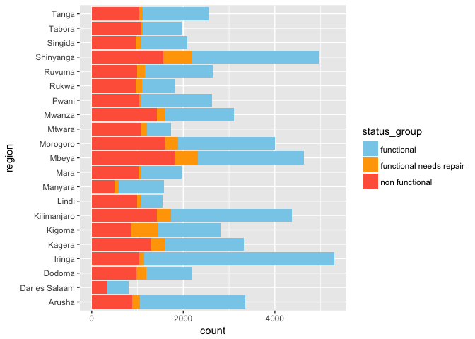

```r
colors <- c("skyblue", "orange", "tomato")
p <- ggplot(secDF) +
  geom_bar(aes(x = region, fill = status_group)) +
  scale_fill_manual(values = colors) +
  coord_flip()
p
```

- grafieken met interactie:

```r
ggplotly(p, width = 900)
```

[interactive chart not shown]

- geographische weergave met interactie (klik op een cirkel voor meer informatie per waterpunt)

```r
selDF <- secDF[1:100,]
pal <- colorFactor(colors, domain = c("functional", "functional needs repair", "non functional"))
leaflet(selDF) %>%
  addTiles() %>%
  setView(lng = mean(selDF$longitude), lat = mean(selDF$latitude), zoom = 6) %>%
  addCircleMarkers(~longitude, ~ latitude, popup = ~wpt_name, color = ~pal(status_group))
```

[interactive chart not shown]

- en nog veel meer.

[figure not shown]